# Introduction to tidygraph & ggraph

Steven Surya Tanujaya

June 29, 2019

# Simple Functionality

You can create a simple graph by using `create_*()` and a random simple graph by using `play_*()`. The baseR `plot()` function also works on this object.

```r
#Create
create_ring(8)
```

```
## # A tbl_graph: 8 nodes and 8 edges
## #
## # An undirected simple graph with 1 component
## #
## # Node Data: 8 x 0 (active)
## #
## # Edge Data: 8 x 2
##    from    to
##   <int> <int>
## 1     1     2
## 2     2     3
## 3     3     4
## # ... with 5 more rows
```

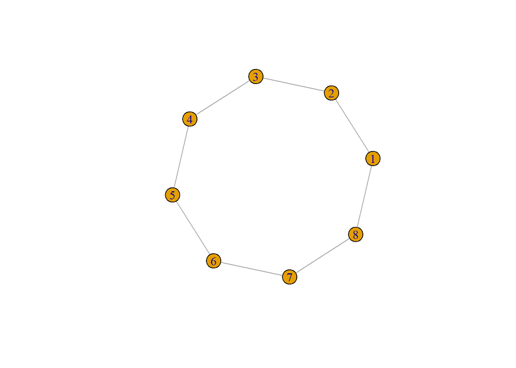

```r
plot(create_ring(8))
```

```r
#Play
set.seed(13)
play_erdos_renyi(n = 8,m=13)
```

```
## # A tbl_graph: 8 nodes and 13 edges
## #
## # A directed simple graph with 1 component
## #
## # Node Data: 8 x 0 (active)
## #
## # Edge Data: 13 x 2
##    from    to
##   <int> <int>
## 1     1     6
## 2     2     3
## 3     3     4
## # ... with 10 more rows
```

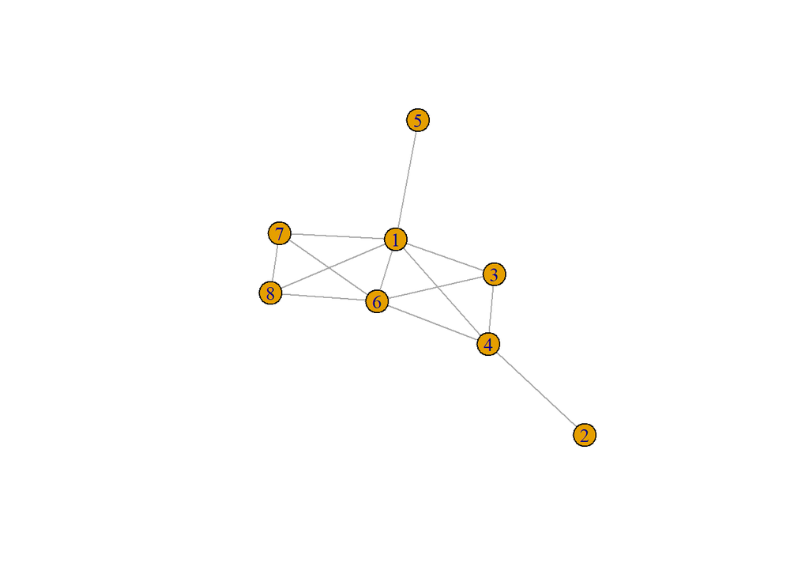

```r
plot(play_erdos_renyi(n = 8,m=13,directed=F))
```

```r
play_erdos_renyi(n=8,p=0.2,directed = F)
```

```
## # A tbl_graph: 8 nodes and 5 edges
## #
## # An undirected simple graph with 3 components
## #
## # Node Data: 8 x 0 (active)
## #
## # Edge Data: 5 x 2
##    from    to
##   <int> <int>
## 1     1     3
## 2     3     4
## 3     3     5
## # ... with 2 more rows
```

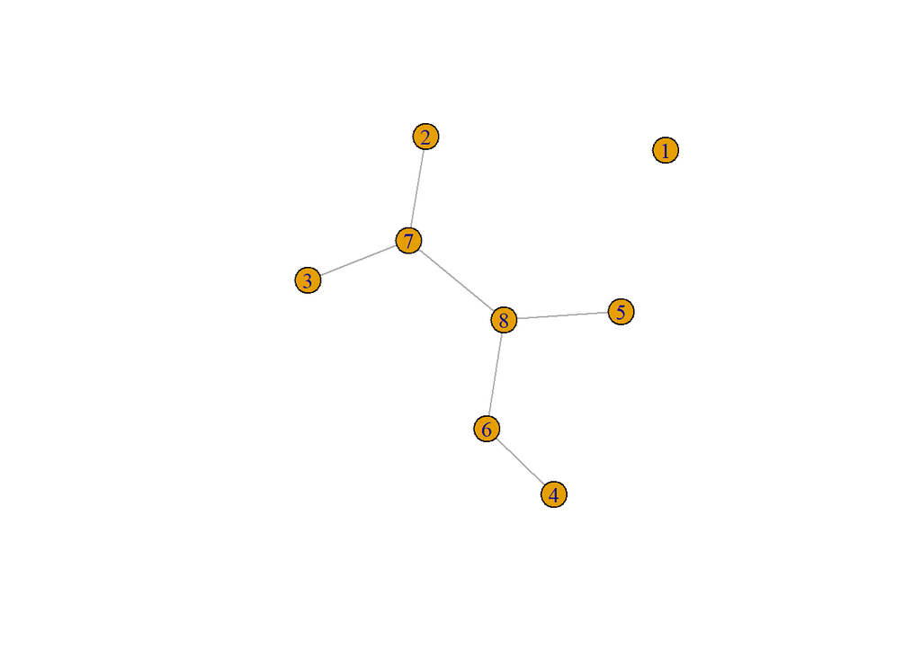

```r
plot(play_erdos_renyi(n=8,p=0.2,directed=F))
```

Here I use media dataset to demonstrate the `tidygraph` and `ggraph` packages. You can create graph object using `tbl_graph` by providing nodes and edges dataset.

```r
media.edge<-read.csv("data/Dataset1-Media-Example-EDGES.csv")
media.node<-read.csv("data/Dataset1-Media-Example-NODES.csv")

media<-tbl_graph(media.node,media.edge)
media
```

```
## # A tbl_graph: 17 nodes and 52 edges
## #
## # A directed multigraph with 1 component
## #
## # Node Data: 17 x 5 (active)
##   id    media               media.type type.label audience.size
##   <fct> <fct>                    <int> <fct>              <int>
## 1 s01   NY Times                     1 Newspaper             20
## 2 s02   Washington Post              1 Newspaper             25
## 3 s03   Wall Street Journal          1 Newspaper             30
## 4 s04   USA Today                    1 Newspaper             32
## 5 s05   LA Times                     1 Newspaper             20
## 6 s06   New York Post                1 Newspaper             50
## # ... with 11 more rows
## #
## # Edge Data: 52 x 4
##    from    to weight type
##   <int> <int>  <int> <fct>
## 1     1     2     10 hyperlink
## 2     1     2     12 hyperlink
## 3     1     3     22 hyperlink
## # ... with 49 more rows
```

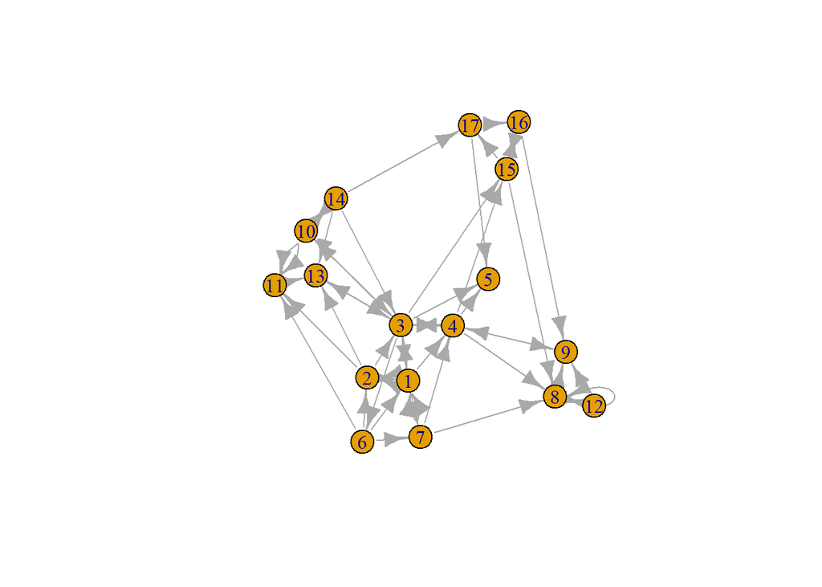

```r
plot(media)
```

There is `activate()` function to access the nodes or the edges dataset. Since `tidygraph` was built under `dplyr` environment, any functionality in `dplyr` package is also can be accessed.

```r
media %>% activate(edges) %>% as_tibble()
```

```
## # A tibble: 52 x 4
##     from    to weight type
##    <int> <int>  <int> <fct>
##  1     1     2     10 hyperlink
##  2     1     2     12 hyperlink
##  3     1     3     22 hyperlink
##  4     1     4     21 hyperlink
##  5     4     5     22 mention
##  6     6     7     21 mention
##  7     8     9     21 mention
##  8    10    11     11 mention
##  9    10    11     12 mention
## 10     3     4     22 hyperlink
## # ... with 42 more rows
```

```r
media %>% activate(nodes) %>% as_tibble()
```

```
## # A tibble: 17 x 5
##    id    media               media.type type.label audience.size
##    <fct> <fct>                    <int> <fct>              <int>
##  1 s01   NY Times                     1 Newspaper             20
##  2 s02   Washington Post              1 Newspaper             25
##  3 s03   Wall Street Journal          1 Newspaper             30
##  4 s04   USA Today                    1 Newspaper             32
##  5 s05   LA Times                     1 Newspaper             20
##  6 s06   New York Post                1 Newspaper             50
##  7 s07   CNN                          2 TV                    56
##  8 s08   MSNBC                        2 TV                    34
##  9 s09   FOX News                     2 TV                    60
## 10 s10   ABC                          2 TV                    23
## 11 s11   BBC                          2 TV                    34
## 12 s12   Yahoo News                   3 Online                33
## 13 s13   Google News                  3 Online                23
## 14 s14   Reuters.com                  3 Online                12
## 15 s15   NYTimes.com                  3 Online                24
## 16 s16   WashingtonPost.com           3 Online                28
## 17 s17   AOL.com                      3 Online                33
```

```r
media_list<-media %>% activate(nodes) %>% pull(media)
media_list
```

```
##  [1] NY Times            Washington Post     Wall Street Journal
##  [4] USA Today           LA Times            New York Post
##  [7] CNN                 MSNBC               FOX News
## [10] ABC                 BBC                 Yahoo News
## [13] Google News         Reuters.com         NYTimes.com
## [16] WashingtonPost.com  AOL.com
## 17 Levels: ABC AOL.com BBC CNN FOX News Google News LA Times ... Yahoo News
```

Here is some example of how you subset the graph based on certain category.

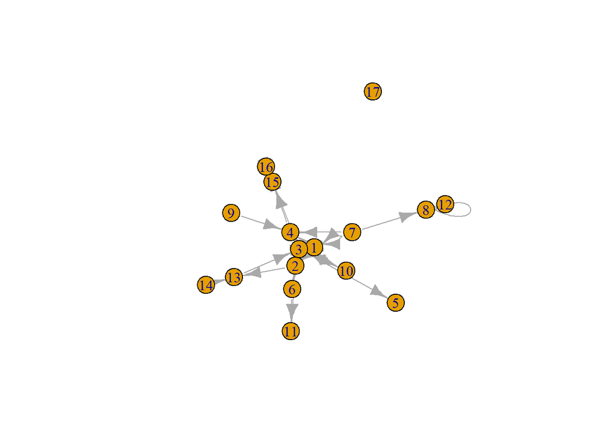

```r
media_h <- media %>% activate(edges) %>% filter(type=="hyperlink")
plot(media_h)
```

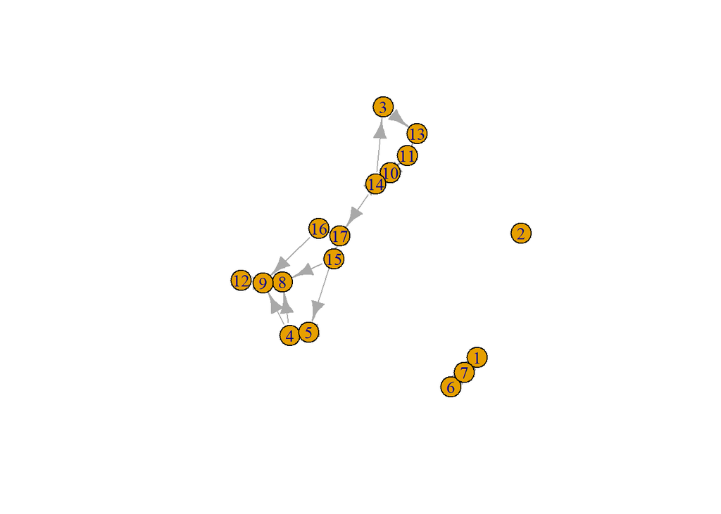

```r
media_m <- media %>% activate(edges) %>% filter(type=="mention")
plot(media_m)
```

Lastly, you can also join and bind some graph. See the results below to observe about the difference between `graph_join()` and `bind_graphs()`.

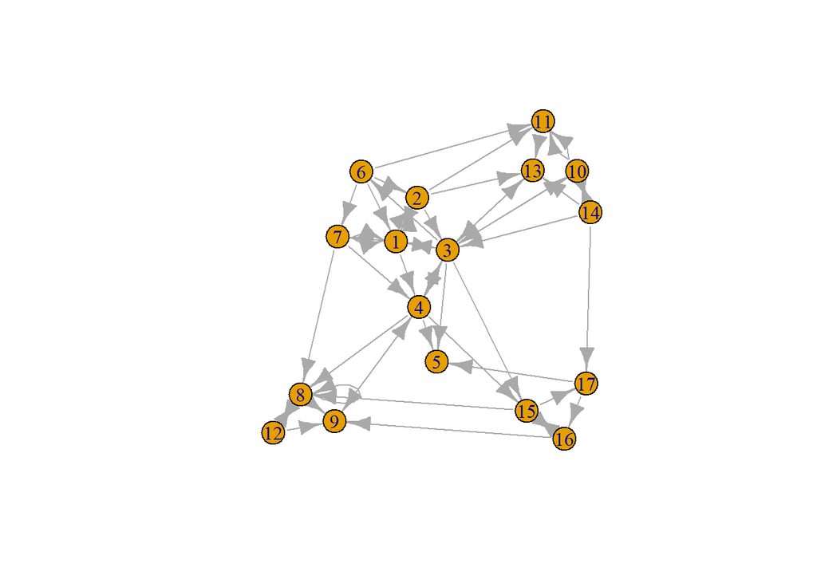

```r
set.seed(100)
media_m %>% graph_join(media_h) %>% plot()
```

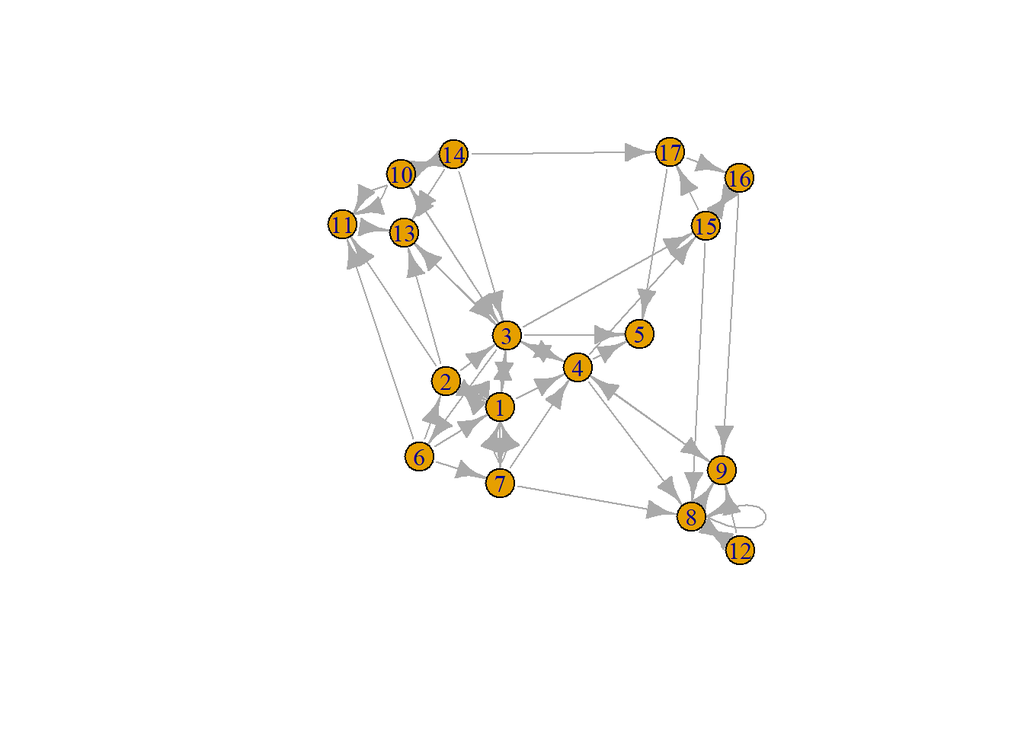

```r
media %>% plot()
```

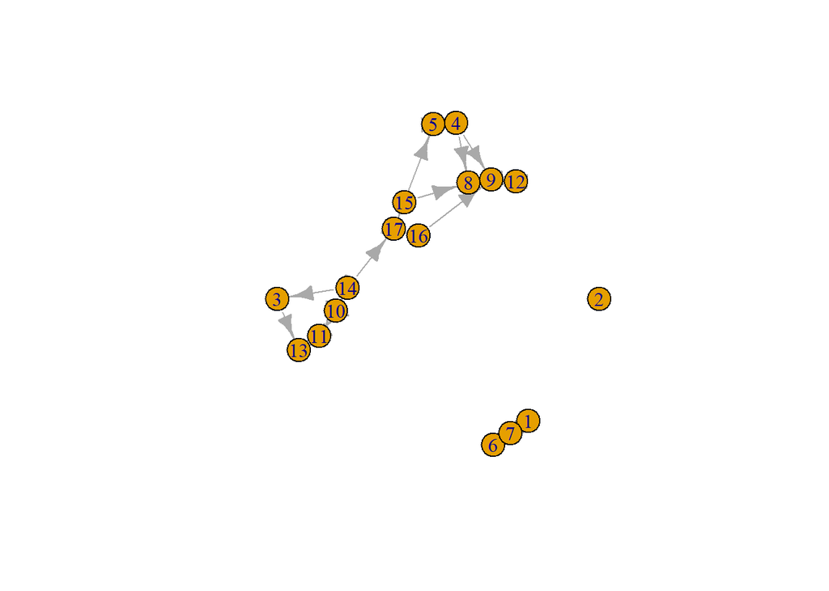

```r
media_m %>% plot()
```

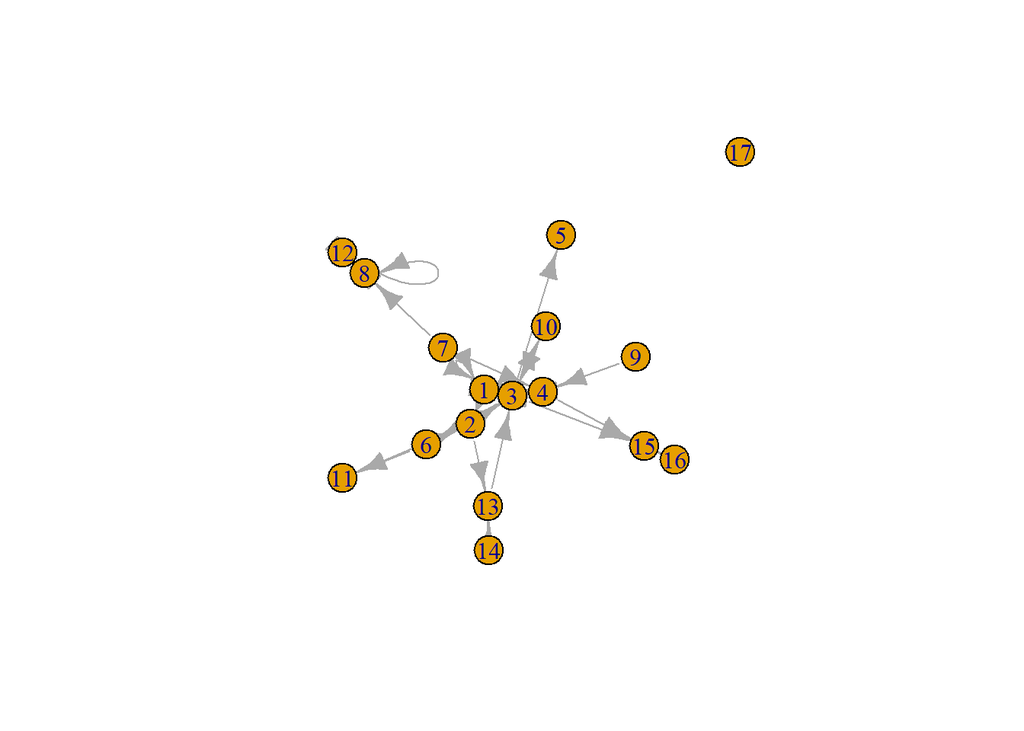

```r
media_h %>% plot()
```

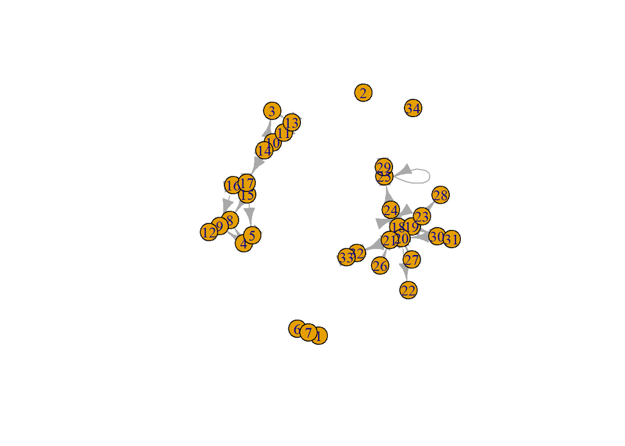

```r
media_m %>% bind_graphs(media_h) %>% plot()
```

# Ggraph Package

From now and so on, I just use `media_m` as a dataset. `ggraph` package uses some similar property as in `igraph` package and same grammar as in `ggplot` package. You can access graph layout from `igraph` to be implemented in `ggraph`. The layout list can be viewed by typing `layout_with_` (and click ‘tab’ button) in `igraph` package. Once you decide to use `layout_with_*` from `igraph` in `ggraph`, you can just add `layout=*` as input in `ggraph` function.

The standard graph visualization is as follows.

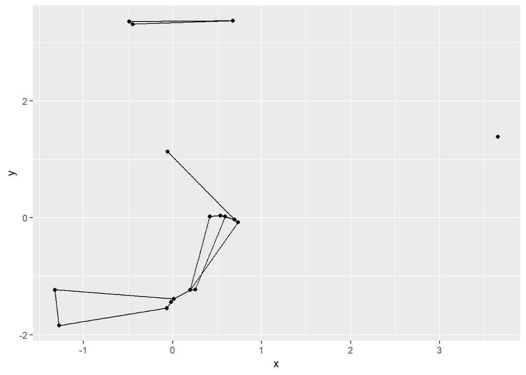

```r
media_m %>%
  ggraph(layout = "kk") +
    geom_node_point() +
    geom_edge_link()
```

Here, you can adjust the node and edge style using some provided style in `ggraph` by using `geom_node_*` and `geom_edge_*`.

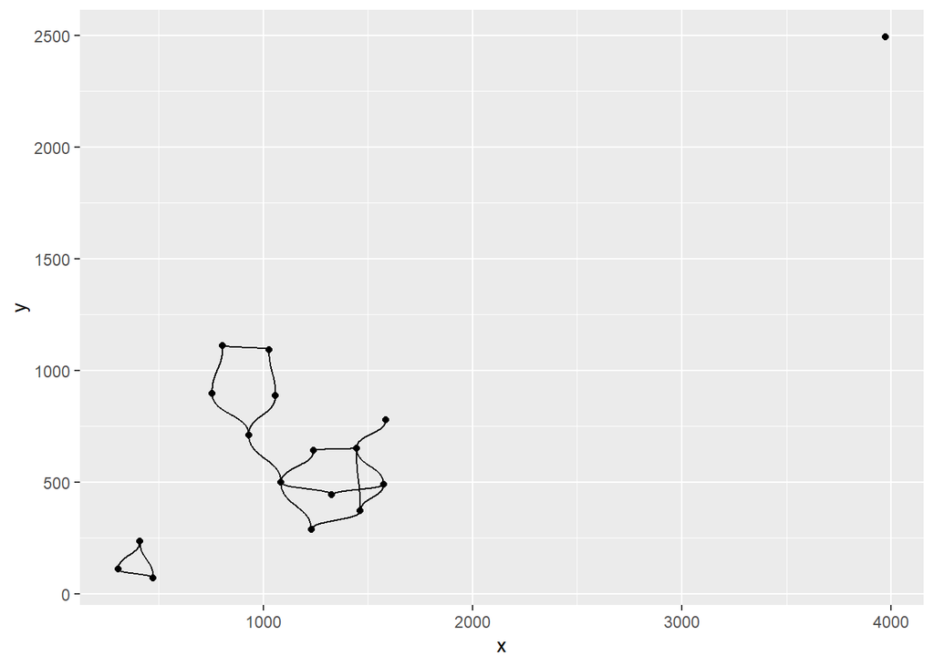

```r
media_m %>%
  ggraph(layout = "gem") +
    geom_node_point() +
    geom_edge_diagonal()
```

Furthermore, there are some visualization techniques, using `aes()` such as in `ggplot()`. You can also use theme here.

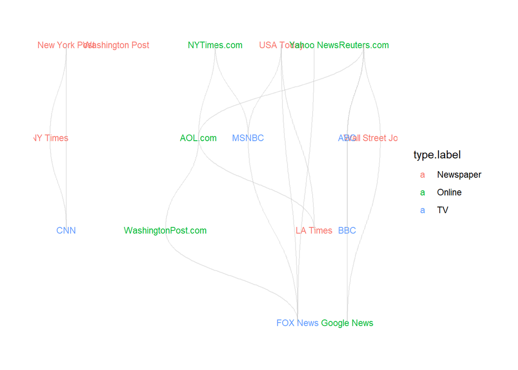

```r
media_m %>%
  ggraph(layout = "sugiyama") +
    geom_node_text(aes(label = media, color = type.label), size=3) +     geom_edge_diagonal(color = "gray", alpha = 0.4) +theme_graph()
```

Notice that the direction/arrow of edges are not appear, so the graph is interpreted as undirected graph. You can just add `arrow()` attribute in order to make it appears.

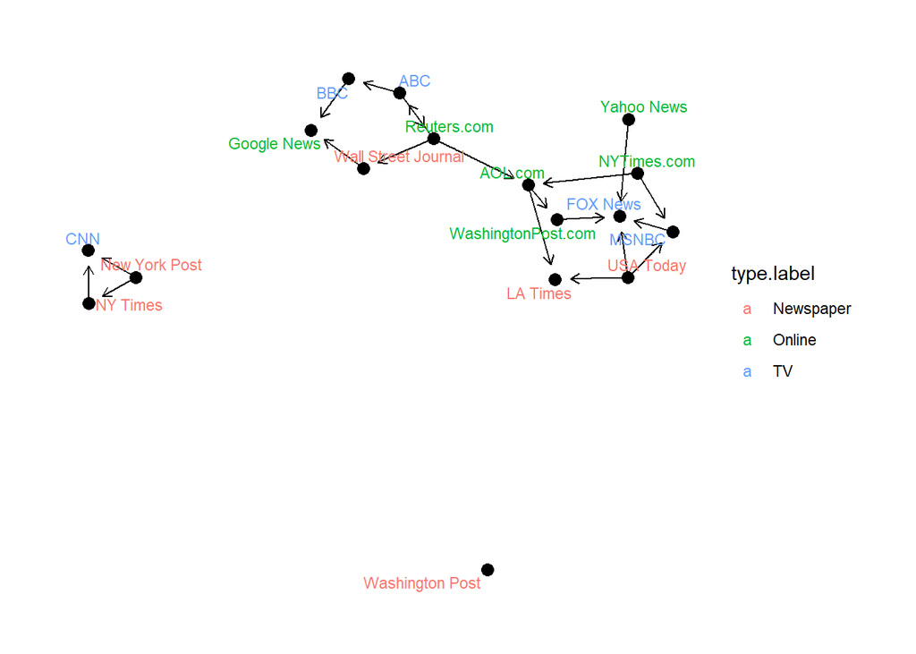

```r
set.seed(100)
media_m %>%
ggraph(layout = 'graphopt') +
    geom_edge_link(arrow = arrow(length = unit(2, 'mm')),
                   end_cap = circle(3, 'mm')) +
    geom_node_point(size = 3) +  geom_node_text(aes(label = media, color = type.label), size=3,repel = T) + theme_graph()
```

Facetting graph using some category is also possible.

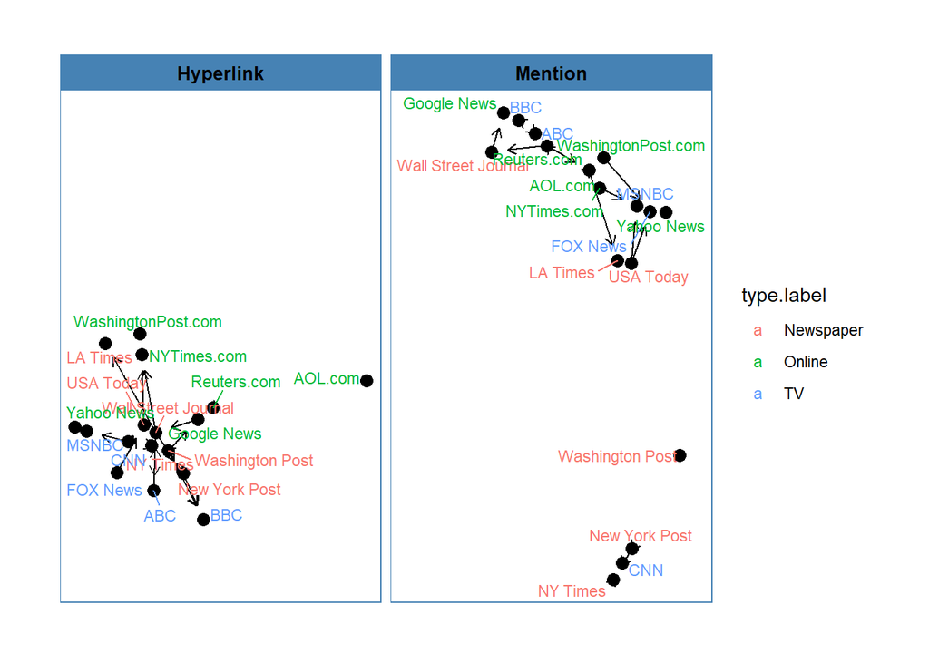

```r
media_m1<-media_m %>% activate(nodes)%>%  mutate(graph="Mention")
media_h1<-media_h %>% activate(nodes)%>%  mutate(graph="Hyperlink")

ggraph(bind_graphs(media_m1,media_h1), layout = 'nicely') +
    geom_edge_link(arrow = arrow(length = unit(2, 'mm')),
                   end_cap = circle(3, 'mm')) +
    geom_node_point(size = 3) +  geom_node_text(aes(label = media, color = type.label), size=3,repel = T) +
    facet_nodes(~graph) +
    theme_graph(foreground = 'steelblue')
```

# Graph Manipulation

Here, `morph()` function is introduced. This function play a crucial role in graph manipulation, it provides us with some graph manipulation techniques that can be applied without changing the graph structure. For example, here I demonstrate how to find the shortest path between “Reuters.com” and “FOX News”.

```r
from <- which(media_list == "Reuters.com")
to <-  which(media_list == "FOX News")

shortest <- media_m %>%
  morph(to_shortest_path, from, to, weights = weight)

#example of unmorph() to create new tbl_graph
shortest %>%
  mutate(selected_node = TRUE) %>%
  unmorph()
```

```
## # A tbl_graph: 17 nodes and 21 edges
## #
## # A directed multigraph with 3 components
## #
## # Edge Data: 21 x 5 (active)
##    from    to weight type    selected_node
##   <int> <int>  <int> <fct>   <lgl>
## 1     4     5     22 mention NA
## 2     6     7     21 mention NA
## 3     8     9     21 mention NA
## 4    10    11     11 mention NA
## 5    10    11     12 mention NA
## 6     1     7     20 mention NA
## # ... with 15 more rows
## #
## # Node Data: 17 x 5
##   id    media               media.type type.label audience.size
##   <fct> <fct>                    <int> <fct>              <int>
## 1 s01   NY Times                     1 Newspaper             20
## 2 s02   Washington Post              1 Newspaper             25
## 3 s03   Wall Street Journal          1 Newspaper             30
## # ... with 14 more rows
```

```r
shortest <- shortest %>%
  activate(nodes) %>%
  mutate(selected_node = TRUE) %>%
  activate(edges) %>%
  mutate(selected_edge = TRUE) %>%
  unmorph()

shortest %>% activate(edges) %>% as_tibble()
```

```
## # A tibble: 21 x 5
##     from    to weight type    selected_edge
##    <int> <int>  <int> <fct>   <lgl>
##  1     4     5     22 mention NA
##  2     6     7     21 mention NA
##  3     8     9     21 mention NA
##  4    10    11     11 mention NA
##  5    10    11     12 mention NA
##  6     1     7     20 mention NA
##  7    12     9     21 mention NA
##  8    11    13     21 mention NA
##  9    10    14     21 mention NA
## 10    14    10     22 mention NA
## # ... with 11 more rows
```

```r
shortest %>% activate(nodes) %>% as_tibble()
```

```
## # A tibble: 17 x 6
##    id    media            media.type type.label audience.size selected_node
##    <fct> <fct>                 <int> <fct>              <int> <lgl>
##  1 s01   NY Times                  1 Newspaper             20 NA
##  2 s02   Washington Post           1 Newspaper             25 NA
##  3 s03   Wall Street Jou~          1 Newspaper             30 NA
##  4 s04   USA Today                 1 Newspaper             32 NA
##  5 s05   LA Times                  1 Newspaper             20 NA
##  6 s06   New York Post             1 Newspaper             50 NA
##  7 s07   CNN                       2 TV                    56 NA
##  8 s08   MSNBC                     2 TV                    34 NA
##  9 s09   FOX News                  2 TV                    60 TRUE
## 10 s10   ABC                       2 TV                    23 NA
## 11 s11   BBC                       2 TV                    34 NA
## 12 s12   Yahoo News                3 Online                33 NA
## 13 s13   Google News               3 Online                23 NA
## 14 s14   Reuters.com               3 Online                12 TRUE
## 15 s15   NYTimes.com               3 Online                24 NA
## 16 s16   WashingtonPost.~          3 Online                28 TRUE
## 17 s17   AOL.com                   3 Online                33 TRUE
```

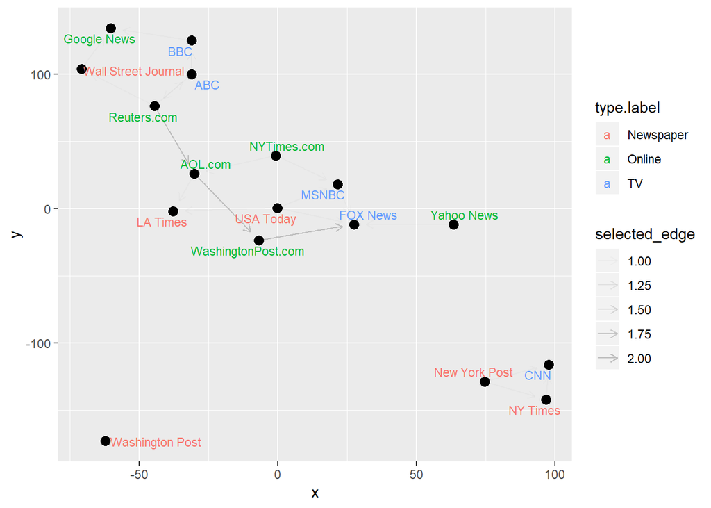

```r
#Label the NA with 1 and True with 2, then order them
shortest <- shortest %>%
  activate(nodes) %>%
  mutate(selected_node = ifelse(is.na(selected_node), 1, 2)) %>%
  activate(edges) %>%
  mutate(selected_edge = ifelse(is.na(selected_edge), 1, 2)) %>%
  arrange(selected_edge)

shortest %>%
ggraph(layout = 'graphopt') +
    geom_edge_link(aes(alpha=selected_edge),color="gray", arrow = arrow(length = unit(2, 'mm')),
                   end_cap = circle(3, 'mm')) +
    geom_node_point(size = 3) +  geom_node_text(aes(label = media, color = type.label), size=3,repel = T)
```

Additional: Centrality measurement There are some measurements of centrality in graph, some of them are provided in `tidygraph`. They can ne accessed through `centrality_*` when you ‘activate’ nodes of the graph.

For instance, `centrality_betweeness()` measure the centrality of every nodes by calculating how many shortest path containing that node in the network. This can be visualized to give you information about how important each node in the term of graph/network connectivity.

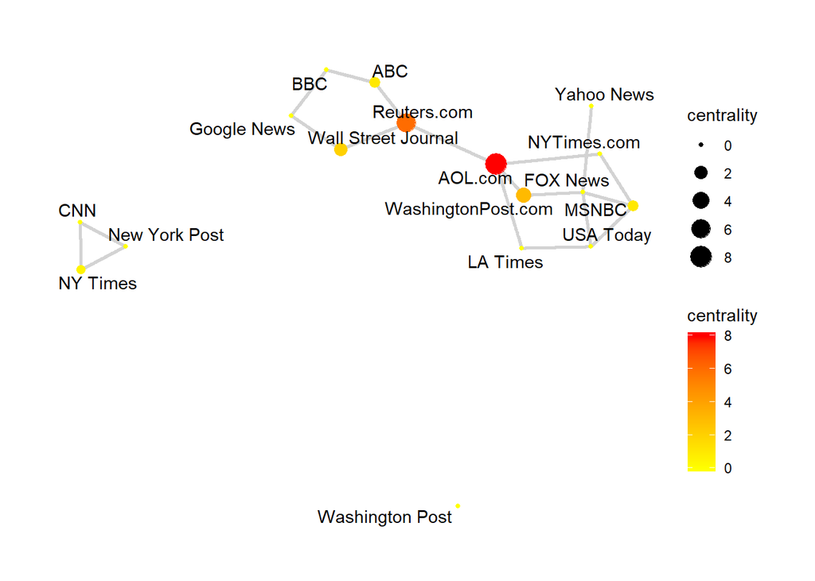

```r
set.seed(100)
media_m %>%
  activate(nodes) %>%
  mutate(centrality = centrality_betweenness()) %>%
  ggraph(layout = "graphopt") +
  geom_edge_link(width = 1, colour = "lightgray") +
  geom_node_point(aes(size = centrality, colour = centrality)) +
  geom_node_text(aes(label = media), repel = TRUE)+
  scale_color_gradient(low = "yellow", high = "red")+
  theme_graph()
```

Reference:

- https://rviews.rstudio.com/2019/03/06/intro-to-graph-analysis/
- http://www.sthda.com/english/articles/33-social-network-analysis/136-network-analysis-and-manipulation-using-r/
- https://www.data-imaginist.com/2017/introducing-tidygraph/
- https://github.com/thomasp85/tidygraph